# c01lpic

Простейшая сеть Используем коммутатор Подключение к сетевому оборудованию Используем технологию VLAN Устранение петель - STP Агрегация каналов - EtherChannel Используем коммутатор третьего уровня Используем маршрутизатор Используем DHCP-протокол Статическая маршрутизация Динамическая маршрутизация NAT Используем межсетевой экран Настраиваем списки доступа Выделяем DMZ Строим VPN Используем NTP сервер Используем SYSLOG сервер Используем AAA сервер WiFi сети Траблшутинг Типовые схемы

[netskills](http://blog.netskills.ru/)  
[download](http://blog.netskills.ru/2018/09/cisco-packet-tracer-7-2-download.html)  
[6.Видео уроки Cisco Packet Tracer. Курс молодого бойца. STP](https://www.youtube.com/watch?v=SyT12mxtFDg&list=PLcDkQ2Au8aVNYsqGsxRQxYyQijILa94T9&index=7)

`C:\Program Files\Cisco Packet Tracer 7.2.1` -  
`Cisco Packet Tracer` -  
`-` -  
`-` -

#### Используем технологию VLAN

[output not shown]

```
Switch>en
Switch#conf t
Enter configuration commands, one per line.  End with CNTL/Z.
Switch(config)#vlan 3
Switch(config-vlan)#name users
Switch(config-vlan)#exit
Switch(config)#interface fa0/3
Switch(config-if)#switchport mode access
Switch(config-if)#switchport access vlan 3
Switch(config-if)#exit
Switch#conf t
Enter configuration commands, one per line.  End with CNTL/Z.
Switch(config)#interface fa0/4
Switch(config-if)#switchport mode access
Switch(config-if)#switchport access vlan 3
Switch(config-if)#end
Switch#
Switch#show vlan brief

VLAN Name                             Status    Ports
---- -------------------------------- --------- -------------------------------
1    default                          active    Fa0/5, Fa0/6, Fa0/7, Fa0/8
                                                Fa0/9, Fa0/10, Fa0/11, Fa0/12
                                                Fa0/13, Fa0/14, Fa0/15, Fa0/16
                                                Fa0/17, Fa0/18, Fa0/19, Fa0/20
                                                Fa0/21, Fa0/22, Fa0/23, Fa0/24
                                                Gig0/1, Gig0/2
2    buh                              active    Fa0/1, Fa0/2
3    users                            active    Fa0/3, Fa0/4
4    VLAN0004                         active
1002 fddi-default                     active
1003 token-ring-default               active
1004 fddinet-default                  active
1005 trnet-default                    active
Switch#
```

`192.168.2.1` - pc0  
`192.168.2.2` - pc1  
`192.168.3.1` - pc2  
`192.168.3.2` - pc3  
`C:\>ping 192.168.2.2` - pc0  
`C:\>ping 192.168.3.2` - pc2

```
Switch#show mac address-table
          Mac Address Table
-------------------------------------------

Vlan    Mac Address       Type        Ports
----    -----------       --------    -----

   2    0001.c7e6.3d59    DYNAMIC     Fa0/1
   2    0060.47ba.5501    DYNAMIC     Fa0/2
   3    000c.8506.96d4    DYNAMIC     Fa0/3
   3    0030.f2b9.9d2c    DYNAMIC     Fa0/4
```

`Switch#show run`

```
!
interface FastEthernet0/1
 switchport access vlan 2
 switchport mode access
!
interface FastEthernet0/2
 switchport access vlan 2
 switchport mode access
!
interface FastEthernet0/3
 switchport access vlan 3
 switchport mode access
!
interface FastEthernet0/4
 switchport access vlan 3
 switchport mode access
!
```

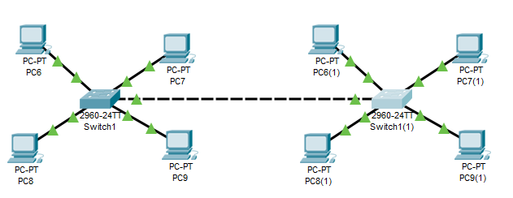

```
Switch#conf t
Enter configuration commands, one per line.  End with CNTL/Z.
Switch(config)#interface gigabitEthernet 0/1
Switch(config-if)#switchport mode trunk

Switch(config-if)#
%LINEPROTO-5-UPDOWN: Line protocol on Interface GigabitEthernet0/1, changed state to down

%LINEPROTO-5-UPDOWN: Line protocol on Interface GigabitEthernet0/1, changed state to up

Switch(config-if)#switchport trunk allowed vlan 2,3
Switch(config-if)#exit
Switch(config)#
```

`C:\>ping 192.168.2.4`

##### Исключить из trunk

```
Switch(config)#interface  gigabitEthernet 0/1
Switch(config-if)#switchport trunk allowed vlan 2
Switch(config-if)#end
Switch#
```

#### Устранение петель - STP

##### Lesson6

Spanning Tree Protocol (STP, протокол покрывающего дерева) — канальный протокол.

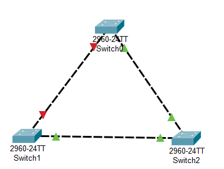

##### Switch 0

```
Switch#show spanning-tree
VLAN0001
  Spanning tree enabled protocol ieee
  Root ID    Priority    32769
             Address     000D.BD6E.6C50
             This bridge is the root
             Hello Time  2 sec  Max Age 20 sec  Forward Delay 15 sec

  Bridge ID  Priority    32769  (priority 32768 sys-id-ext 1)
             Address     000D.BD6E.6C50
             Hello Time  2 sec  Max Age 20 sec  Forward Delay 15 sec
             Aging Time  20

Interface        Role Sts Cost      Prio.Nbr Type
---------------- ---- --- --------- -------- --------------------------------
Fa0/1            Desg FWD 19        128.1    P2p
Fa0/2            Desg FWD 19        128.2    P2p
```

##### Switch 1

```
Switch#show spanning-tree
VLAN0001
  Spanning tree enabled protocol ieee
  Root ID    Priority    32769
             Address     000D.BD6E.6C50
             Cost        19
             Port        1(FastEthernet0/1)
             Hello Time  2 sec  Max Age 20 sec  Forward Delay 15 sec

  Bridge ID  Priority    32769  (priority 32768 sys-id-ext 1)
             Address     00D0.D304.4D15
             Hello Time  2 sec  Max Age 20 sec  Forward Delay 15 sec
             Aging Time  20

Interface        Role Sts Cost      Prio.Nbr Type
---------------- ---- --- --------- -------- --------------------------------
Fa0/1            Root FWD 19        128.1    P2p
Fa0/2            Altn BLK 19        128.2    P2p
```

##### Switch 2

```
Switch#show spanning-tree
VLAN0001
  Spanning tree enabled protocol ieee
  Root ID    Priority    32769
             Address     000D.BD6E.6C50
             Cost        19
             Port        1(FastEthernet0/1)
             Hello Time  2 sec  Max Age 20 sec  Forward Delay 15 sec

  Bridge ID  Priority    32769  (priority 32768 sys-id-ext 1)
             Address     0060.7046.DE52
             Hello Time  2 sec  Max Age 20 sec  Forward Delay 15 sec
             Aging Time  20

Interface        Role Sts Cost      Prio.Nbr Type
---------------- ---- --- --------- -------- --------------------------------
Fa0/1            Root FWD 19        128.1    P2p
Fa0/2            Desg FWD 19        128.2    P2p
```

*Выключим порт*  
`Fa0/1` - Switch 1

```
Switch#configure terminal
Enter configuration commands, one per line.  End with CNTL/Z.
Switch(config)#interface fa0/1
Switch(config-if)#shutdown
```

interface fa0/1  
`shutdown` - no shutdown - включить  
`show running-config` - interface FastEthernet0/1 shutdown  
`BLK` - show spanning-tree  
`LRN` - Sts  
`FWD` -  
`-` -

#### Другой пример

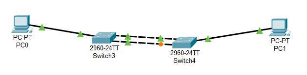

`This bridge is the root` - Switch3

```
Fa0/1            Root FWD 19        128.1    P2p
Fa0/2            Altn BLK 19        128.2    P2p
Fa0/3            Desg FWD 19        128.3    P2p
```

- Switch4  
`configure terminal` -  
`interface fastEthernet 1/0` -  
`shutdown` -

```
Reply from 192.168.1.2: bytes=32 time<1ms TTL=128
Request timed out.
Request timed out.
Request timed out.
Request timed out.
Request timed out.
Reply from 192.168.1.2: bytes=32 time=1ms TTL=128
```

##### RSTP

`Switch(config)#spanning-tree mode rapid-pvst` - Switch3, Switch4  
`show spanning-tree` - Spanning tree enabled protocol rstp  
`` -

```
Reply from 192.168.1.2: bytes=32 time<1ms TTL=128
Request timed out.
Reply from 192.168.1.2: bytes=32 time=11ms TTL=128
```

#### Агрегация каналов - EtherChannel

##### Lesson7

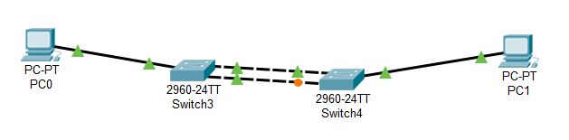

`Switch(config)#interface range fastEthernet 0/1-2` -  
`Switch(config-if-range)#channel-group 1 mode on` - Creating a port-channel interface Port-channel 1  
`end` -

##### trunk

trunk нужен для включения туда vlan-ов  
организуется не на физических, а на логических портах  
`interface port-channel 1` -  
`switchport mode trunk` -  
`-` -

```
interface Port-channel1
 switchport mode trunk
!
interface FastEthernet0/1
 switchport mode trunk
 channel-group 1 mode on
!
interface FastEthernet0/2
 switchport mode trunk
 channel-group 1 mode on
```

##### Динамическое агрегирование третьего уровня

`3560-24PS` - Multilayer Switch0  
`-` -

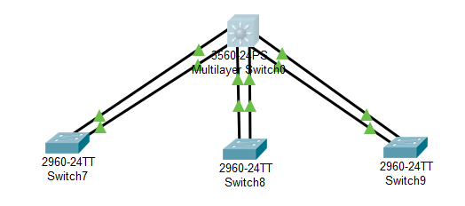

`write memory` - Building configuration... [OK]  
`Switch(config)#interface range fastEthernet 0/1-2` -  
`Switch(config-if-range)#channel-protocol lacp` -  
`Switch(config-if-range)#channel-group 1 mode active` - Creating a port-channel interface Port-channel 1  
`Switch(config-if-range)#exit` -

```
Switch(config)#interface range fastEthernet 0/3-4
Switch(config-if-range)#channel-protocol lacp
Switch(config-if-range)#channel-group 2 mode active
Switch(config-if-range)#
Creating a port-channel interface Port-channel 2

Switch(config-if-range)#exit
Switch(config)#interface range fastEthernet 0/5-6
Switch(config-if-range)#channel-protocol lacp
Switch(config-if-range)#channel-group 3 mode active
Switch(config-if-range)#
Creating a port-channel interface Port-channel 3
```

`show etherchannel summary` -

```
Group  Port-channel  Protocol    Ports
------+-------------+-----------+----------------
1      Po1(SU)           LACP   Fa0/1(P) Fa0/2(P)
2      Po2(SU)           LACP   Fa0/3(P) Fa0/4(P)
3      Po3(SU)           LACP   Fa0/5(P) Fa0/6(P)
```

`Switch>show etherchannel port-channel` -

`Switch>show etherchannel port-channel` -

```
                Channel-group listing:
                ----------------------

Group: 1
----------
                Port-channels in the group:
                ---------------------------

Port-channel: Po1    (Primary Aggregator)
------------

Age of the Port-channel   = 00d:00h:28m:36s
Logical slot/port   = 2/1       Number of ports = 2
GC                  = 0x00000000      HotStandBy port = null
Port state          = Port-channel
Protocol            =   LACP
Port Security       = Disabled

Ports in the Port-channel:

Index   Load   Port     EC state        No of bits
------+------+------+------------------+-----------
  0     00     Fa0/1    Active             0
  0     00     Fa0/2    Active             0
Time since last port bundled:    00d:00h:07m:21s    Fa0/2
Group: 2
----------
                Port-channels in the group:
                ---------------------------

Port-channel: Po2    (Primary Aggregator)
------------

Age of the Port-channel   = 00d:00h:24m:37s
Logical slot/port   = 2/2       Number of ports = 2
GC                  = 0x00000000      HotStandBy port = null
Port state          = Port-channel
Protocol            =   LACP
Port Security       = Disabled

Ports in the Port-channel:

Index   Load   Port     EC state        No of bits
------+------+------+------------------+-----------
  0     00     Fa0/3    Active             0
  0     00     Fa0/4    Active             0
Time since last port bundled:    00d:00h:07m:01s    Fa0/4
Group: 3
----------
                Port-channels in the group:
                ---------------------------

Port-channel: Po3    (Primary Aggregator)
------------

Age of the Port-channel   = 00d:00h:23m:35s
Logical slot/port   = 2/3       Number of ports = 2
GC                  = 0x00000000      HotStandBy port = null
Port state          = Port-channel
Protocol            =   LACP
Port Security       = Disabled

Ports in the Port-channel:

Index   Load   Port     EC state        No of bits
------+------+------+------------------+-----------
  0     00     Fa0/5    Active             0
  0     00     Fa0/6    Active             0
Time since last port bundled:    00d:00h:06m:43s    Fa0/6
Switch>
```

#### Используем коммутатор третьего уровня

[lesson8](https://www.youtube.com/watch?v=Afvm-laWfbM&list=PLcDkQ2Au8aVNYsqGsxRQxYyQijILa94T9&index=9)

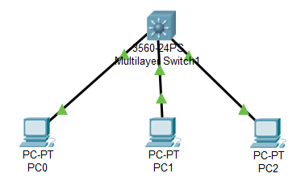

`conf t` -  
`vlan 2` -

```
Switch(config)#vlan 2
Switch(config-vlan)#name ?
  WORD  The ascii name for the VLAN
Switch(config-vlan)#name VLAN2
Switch(config-vlan)#exit
Switch(config)#vlan 3
Switch(config-vlan)#name VLAN3
Switch(config-vlan)#exit
Switch(config)#vlan 4
Switch(config-vlan)#name VLAN4
Switch(config-vlan)#Exit
```

`interface fastEthernet 0/1` -  
`switchport mode access` -  
`switchport access vlan 2` -  
`ex` -  
`interface fastEthernet 0/2` -  
`switchport mode access` -  
`switchport access vlan 3` -  
`ex` -  
`interface fastEthernet 0/3` -  
`switchport mode access` -  
`switchport access vlan 4` -  
`ex` -

```
interface FastEthernet0/1
 switchport access vlan 2
 switchport mode access
 switchport nonegotiate
!
interface FastEthernet0/2
 switchport access vlan 3
 switchport mode access
 switchport nonegotiate
!
interface FastEthernet0/3
 switchport access vlan 4
 switchport mode access
 switchport nonegotiate
```

`interface vlan 2` -  
`ip address 2.2.2.1 255.255.255.0` -  
`ex` -  
`interface vlan 3` -  
`ip address 3.3.3.1 255.255.255.0` -  
`ex` -  
`interface vlan 4` -  
`ip address 4.4.4.1 255.255.255.0` -  
`ex` -

```
interface Vlan2
 mac-address 0009.7c0d.2901
 ip address 2.2.2.1 255.255.255.0
!
interface Vlan3
 mac-address 0009.7c0d.2902
 ip address 3.3.3.1 255.255.255.0
!
interface Vlan4
 mac-address 0009.7c0d.2903
 ip address 4.4.4.1 255.255.255.0
```

PC0, PC1, PC2  
`-` -  
`-` -  
`ip routing` -  
`-` -  
`-` -

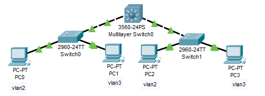

`-` -  
**switch 0,1**

```
Switch>en
Switch#conf t
Switch(config)#interface fastEthernet 0/1
Switch(config-if)#switchport mode access
Switch(config-if)#switchport access vlan 2
% Access VLAN does not exist. Creating vlan 2
Switch(config-if)#ex
Switch(config)#interface fastEthernet 0/2
Switch(config-if)#switchport mode access
Switch(config-if)#switchport access vlan 3
% Access VLAN does not exist. Creating vlan 3
Switch(config-if)#ex
```

**3560, gigabitEthernet 0/1, 0/2**  
`` -

```
Switch>en
Switch#conf t
Switch(config)#interface gigabitEthernet 0/1
Switch(config-if)#switchport mode trunk
Command rejected: An interface whose trunk encapsulation is "Auto" can not be configured to "trunk" mode.
Switch(config-if)#switchport trunk encapsulation dot1q
Switch(config-if)#switchport mode trunk
Switch(config-if)#switchport trunk allowed vlan 2,3
```

```
Switch(config)#interface vlan 2
Switch(config-if)#ip address 2.2.2.1 255.255.255.0
Switch(config-if)#ex
Switch(config)#interface vlan 3
Switch(config-if)#ip address 3.3.3.1 255.255.255.0
Switch(config-if)#end
Switch#wr mem
Building configuration...
[OK]
```

`Switch(config)#ip routing` -

```
Switch(config)#vlan 2
Switch(config-vlan)#
%LINK-5-CHANGED: Interface Vlan2, changed state to up

%LINEPROTO-5-UPDOWN: Line protocol on Interface Vlan2, changed state to up

Switch(config-vlan)#name VLAN2
Switch(config-vlan)#ex
Switch(config)#vl
Switch(config)#vlan 3
Switch(config-vlan)#
%LINK-5-CHANGED: Interface Vlan3, changed state to up

%LINEPROTO-5-UPDOWN: Line protocol on Interface Vlan3, changed state to up

Switch(config-vlan)#name VLAN3
```

#### Используем маршрутизатор

##### Lesson9

**2960** `` -

```
Switch>en
Switch#conf t
Switch(config)#vlan 4
Switch(config-vlan)#name VLAN4
Switch(config)#interface fastEthernet 0/3
Switch(config-if)#switchport mode access
Switch(config-if)#switchport access vlan 4
Switch(config)#interface fastEthernet 0/4
Switch(config-if)#switchport mode trunk
Switch(config-if)#switchport trunk allowed vlan 2,3,4
Switch(config-if)#end
Switch#
%SYS-5-CONFIG_I: Configured from console by console

Switch#wr mem
Building configuration...
[OK]
```

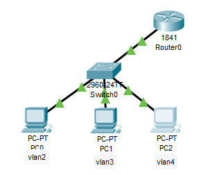

**1841** `` -

```
Router>en
Router#conf t
Router(config)#interface fastEthernet 0/0
Router(config-if)#no shutdown

Router(config-if)#
%LINK-5-CHANGED: Interface FastEthernet0/0, changed state to up

%LINEPROTO-5-UPDOWN: Line protocol on Interface FastEthernet0/0, changed state to up

Router(config-if)#ex
Router(config)#ex
Router#
```

```
Router(config)#interface fastEthernet 0/0.2
Router(config-subif)#encapsulation dot1Q 2
Router(config-subif)#ip address 192.168.2.1 255.255.255.0
Router(config-subif)#no shutdown
Router(config-subif)#ex
```

```
Router(config)#interface fastEthernet 0/0.3
Router(config-subif)#
%LINK-5-CHANGED: Interface FastEthernet0/0.3, changed state to up

%LINEPROTO-5-UPDOWN: Line protocol on Interface FastEthernet0/0.3, changed state to up

Router(config-subif)#encapsulation dot1Q 3
Router(config-subif)#no shutdown
Router(config-subif)#ex
Router(config)#interface fastEthernet 0/0.4
%LINK-5-CHANGED: Interface FastEthernet0/0.4, changed state to up

%LINEPROTO-5-UPDOWN: Line protocol on Interface FastEthernet0/0.4, changed state to up

Router(config-subif)#encapsulation dot1Q 4
Router(config-subif)#no shutdown
Router(config-subif)#ex


Router(config)#interface fastEthernet 0/0.3
Router(config-subif)#ip address 192.168.3.1 255.255.255.0
Router(config)#interface fastEthernet 0/0.4
Router(config-subif)#ip address 192.168.4.1 255.255.255.0
```

```
interface FastEthernet0/0.2
 encapsulation dot1Q 2
 ip address 192.168.2.1 255.255.255.0
!
interface FastEthernet0/0.3
 encapsulation dot1Q 3
 ip address 192.168.3.1 255.255.255.0
!
interface FastEthernet0/0.4
 encapsulation dot1Q 4
 ip address 192.168.4.1 255.255.255.0
```

##### PC3-PC6

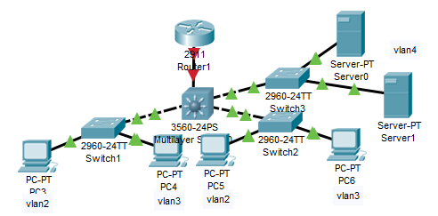

##### Switch1, Switch2

`default interface fastEthernet 0/4` -  
`-` -

```
interface FastEthernet0/1
 switchport access vlan 2
 switchport mode access
!
interface FastEthernet0/2
 switchport access vlan 3
 switchport mode access
!
interface FastEthernet0/3
 switchport trunk allowed vlan 2-3
 switchport mode trunk
```

**Switch3**

```
interface FastEthernet0/1
 switchport access vlan 4
 switchport mode access
!
interface FastEthernet0/2
 switchport access vlan 4
 switchport mode access
!
interface FastEthernet0/3
 switchport trunk allowed vlan 4
 switchport mode trunk
```

**PC** PC3 192.168.22.2 PC4 192.168.33.2 PC5 192.168.22.3 PC6 192.168.33.3 Server0 192.168.44.2 Server1 192.168.44.3

**3560**

```
version 12.2(37)SE1
no service timestamps log datetime msec
no service timestamps debug datetime msec
no service password-encryption
!
hostname Switch
!
ip routing
!
spanning-tree mode pvst
```

```
interface FastEthernet0/1
 switchport trunk allowed vlan 2-3
 switchport trunk encapsulation dot1q
 switchport mode trunk
!
interface FastEthernet0/2
 switchport trunk allowed vlan 2-3
 switchport trunk encapsulation dot1q
 switchport mode trunk
!
interface FastEthernet0/3
 switchport trunk allowed vlan 4
 switchport trunk encapsulation dot1q
 switchport mode trunk
```

```
interface Vlan2
 mac-address 00e0.f7e4.da01
 ip address 192.168.22.1 255.255.255.0
!
interface Vlan3
 mac-address 00e0.f7e4.da02
 ip address 192.168.33.1 255.255.255.0
!
interface Vlan4
 mac-address 00e0.f7e4.da03
 ip address 192.168.44.1 255.255.255.0
```

```
Switch(config)#vlan 5
Switch(config-vlan)#
%LINK-5-CHANGED: Interface Vlan5, changed state to up
Switch(config-vlan)#name vlan5
Switch(config-vlan)#ex
Switch(config)#interface vlan 5
Switch(config-if)#ip address 192.168.55.2 255.255.255.0
Switch(config-if)#no shutdown
```

```
Switch(config)#interface gigabitEthernet 0/1
Switch(config-if)#switchport mode access
Switch(config-if)#switchport access vlan 5
```

```
interface GigabitEthernet0/1
 switchport access vlan 5
 switchport mode access
 switchport nonegotiate
!
interface Vlan5
 mac-address 00e0.f7e4.da04
 ip address 192.168.55.2 255.255.255.0
```

**Router 2911**

```
Router(config)#interface gigabitEthernet 0/0
Router(config-if)#no shutdown
%LINK-5-CHANGED: Interface GigabitEthernet0/0, changed state to up

%LINEPROTO-5-UPDOWN: Line protocol on Interface GigabitEthernet0/0, changed state to up

Router(config-if)#ip address 192.168.55.1 255.255.255.0

Router#ping 192.168.55.2

Sending 5, 100-byte ICMP Echos to 192.168.55.2, timeout is 2 seconds:
.!!!!
Success rate is 80 percent (4/5), round-trip min/avg/max = 0/0/0 ms

Router#ping 192.168.55.3

Type escape sequence to abort.
Sending 5, 100-byte ICMP Echos to 192.168.55.3, timeout is 2 seconds:
.....
Success rate is 0 percent (0/5)
```

#### Статическая маршрутизация

##### lesson10

##### router

```
Router(config)#ip route 192.168.22.0 255.255.255.0 192.168.55.2
Router#ping 192.168.22.2

Type escape sequence to abort.
Sending 5, 100-byte ICMP Echos to 192.168.22.2, timeout is 2 seconds:
!!!!!
Success rate is 100 percent (5/5), round-trip min/avg/max = 0/1/5 ms
```

```
Router(config)#ip route 192.168.22.0 255.255.255.0 192.168.55.2
Router(config)#ip route 192.168.33.0 255.255.255.0 192.168.55.2
Router(config)#ip route 192.168.44.0 255.255.255.0 192.168.55.2
```

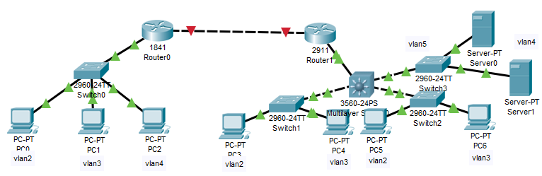

**Router1**

```
Router(config)#int gi 0/1
Router(config-if)#no shutdown
Router(config-if)#ip address 192.168.70.1 255.255.255.252
```

**Router0**

```
Router(config)#int fa 0/1
Router(config-if)#no shutdown
Router(config-if)#ip address 192.168.70.2 255.255.255.252
Router#ping 192.168.70.2

Type escape sequence to abort.
Sending 5, 100-byte ICMP Echos to 192.168.70.2, timeout is 2 seconds:
!!!!!
Success rate is 100 percent (5/5), round-trip min/avg/max = 0/2/9 ms
```

```
ping -n 200 192.168.22.2
Reply from 192.168.2.1: Destination host unreachable.
```

**ip route 0.0.0.0 0.0.0.0 192.168.70.1**

```
C:\>ping -n 200 192.168.22.2
Request timed out.
Request timed out.
Request timed out.
```

```
Router#show ip route
Codes: C - connected, S - static, I - IGRP, R - RIP, M - mobile, B - BGP
       D - EIGRP, EX - EIGRP external, O - OSPF, IA - OSPF inter area
       N1 - OSPF NSSA external type 1, N2 - OSPF NSSA external type 2
       E1 - OSPF external type 1, E2 - OSPF external type 2, E - EGP
       i - IS-IS, L1 - IS-IS level-1, L2 - IS-IS level-2, ia - IS-IS inter area
       * - candidate default, U - per-user static route, o - ODR
       P - periodic downloaded static route

Gateway of last resort is 192.168.70.1 to network 0.0.0.0

C    192.168.2.0/24 is directly connected, FastEthernet0/0.2
C    192.168.3.0/24 is directly connected, FastEthernet0/0.3
C    192.168.4.0/24 is directly connected, FastEthernet0/0.4
     192.168.70.0/30 is subnetted, 1 subnets
C       192.168.70.0 is directly connected, FastEthernet0/1
S*   0.0.0.0/0 [1/0] via 192.168.70.1
```

##### 3560

```
Switch(config)#ip route 0.0.0.0 0.0.0.0 192.168.55.1
```

##### Route1

```
Router(config)#ip route 0.0.0.0 0.0.0.0 192.168.7.2
Router(config)#no ip route 0.0.0.0 0.0.0.0 192.168.7.2
Router(config)#ip route 0.0.0.0 0.0.0.0 192.168.70.2
```

```
C:\>ping -n 200 192.168.22.2Reply from 192.168.22.2: bytes=32 time<1ms TTL=125
```

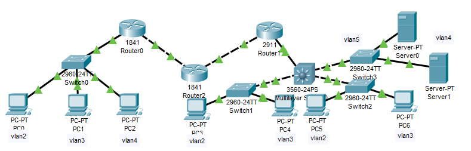

##### 1841

```
Router(config)#int fa 0/0
Router(config-if)#no shutdown
Router(config-if)#ip address 192.168.70.1 255.255.255.0
Router(config)#int fa 0/1
Router(config-if)#no shutdown
Router(config-if)#192.168.80.1 255.255.255.0
```

##### Router0

```
Router(config)#int fa 0/1
Router(config-if)#ip address 192.168.70.2 255.255.255.0
```

##### Router1

```
Router(config-if)#ip address 192.168.80.2 255.255.255.0
Router(config)#no ip route 0.0.0.0 0.0.0.0 192.168.70.2
Router(config)#ip route 0.0.0.0 0.0.0.0 192.168.80.1
```

##### 1841

```
Router(config)#ip route 192.168.2.0 255.255.255.0 192.168.70.2
Router(config)#ip route 192.168.3.0 255.255.255.0 192.168.70.2
Router(config)#ip route 192.168.4.0 255.255.255.0 192.168.70.2
Router(config)#ip route 192.168.22.0 255.255.255.0 192.168.80.2
Router(config)#ip route 192.168.33.0 255.255.255.0 192.168.80.2
Router(config)#ip route 192.168.44.0 255.255.255.0 192.168.80.2
```

#### Используем DHCP-протокол

##### lesson11

#### Динамическая маршрутизация

#### NAT

#### Используем межсетевой экран

#### Настраиваем списки доступа

#### Выделяем DMZ

#### Строим VPN

#### Используем NTP сервер

#### Используем SYSLOG сервер

#### Используем AAA сервер

#### WiFi сети

#### Траблшутинг

#### Типовые схемы

[CISCO: [No] Shutdown — Включить/Выключить Интерфейс](https://www.shellhacks.com/ru/cisco-no-shutdown-command-enable-disable-interface/)  
[Основы компьютерных сетей. Тема №6. Понятие VLAN, Trunk и протоколы VTP и DTP](https://habr.com/ru/post/319080/)  
[lab](https://drive.google.com/drive/folders/0B-5kZl7ixcSKajJOY1lNdC0xNFk)